# LRT: Lineage estimation by integrative analysis of single cell RNA-seq and TCR-seq data

Juan Xie

2022-10-12

# 1 Introduction

This vignette will demonstrate a full T cell trajectory inference workflow, including preprocessing,clonotype-level trajectory estimation, trajectory clustering,pseudotime estimation and trajectory cluster marker prediction.

# 2 Dataset

We will demonstrate the usage of `LRT` via a real dataset from [Khatun et al](https://pubmed.ncbi.nlm.nih.gov/33201171/).This dataset consists of scTCR-seq data and scRNA-seq data from five mice. The raw data can be accessed at https://www.ncbi.nlm.nih.gov/geo/query/acc.cgi?acc=GSE158896.

# 3 Load packages

```r
## load LRT package
library(LRT)
```

The `LRT` package has multiple dependencies, to use it smoothly, it is advised to install the dependencies before using LRT.

```r
## load dependencies

packages <- c("Seurat", "dplyr", "tibble","dtwclust", "progress", "DT", "shiny", "shinyBS","ggplot2",'sbm','pheatmap')

# Install packages not yet installed
installed_packages <- packages %in% rownames(installed.packages())
if (any(installed_packages == FALSE)) {
  install.packages(packages[!installed_packages])
}
# Packages loading
invisible(lapply(packages, library, character.only = TRUE))

if (!require("BiocManager", quietly = TRUE))
    install.packages("BiocManager")

BiocManager::install("slingshot","SingleCellExperiment","tradeSeq")
```

# 4 Data preprocessing

To begin our analysis of the clonotye lineage, we need to prepare a dataframe containing clonotype information and a seurat object containing cell id, UMAP coordinates and clustering labels.

An example R code is provided at https://github.com/JuanXie19/LRT/blob/master/preprocess.r, which illustrates the data pre-processing step and prepares the input for our analysis.

# 5 Combine scTCR-seq and scRNA-seq data

After pre-processing, we need to attach the clonotype information from scTCR-seq to the seurat object.

For the clonotype information,you can choose anything you like, as long as it can be used to define clonotype. Common choices are CDR3 amino acid/nucleotide sequence (either $\alpha$ chain, $\beta$ chain or paired $\alpha \beta$ chain). Note that the clonotype information must be saved in a column named ‘cdr3’ in the scTCR-seq data. An example pre-processed seurat object is provided at https://drive.google.com/file/d/17r8WkAIyLmGwaEP4wLHnQkF2nvWDXUPd/view?usp=sharing, and example scTCR-seq data is provided at https://drive.google.com/file/d/1P80GIvhpcZS6ss3m-gf4MwYFJw8UQiKg/view?usp=sharing. Users can download these example data and explore the functions.

To combine scTCR-seq and scRNA-seq data, users can simply call the `getCombinedDataSet` function.

```r
# load TCR data
TCR <-read.csv('/path/to/scTCR-seqData/TCR.csv')

# load seurat object with clustering labels and UMAP coordinates
load('Mice.sub2.rda')

# combine TCR and scRNA-seq
Combined <- getCombinedDataSet(TCR, Mice.sub2)
```

The combined dataset is an updated Seurat object. Users could directly access the object via `@seurat`. They can also easily access the components (seurat cluster labels and TCR sequences) by calling the corresponding accessor functions:

```r
# have a look at the combined dataset
Combined
```

```
#> An object of class "CombinedDataSet"
#> Slot "seurat":
#> An object of class Seurat
#> 45449 features across 7395 samples within 3 assays
#> Active assay: integrated (3000 features, 3000 variable features)
#>  2 other assays present: RNA, SCT
#>  3 dimensional reductions calculated: pca, umap, tsne
```

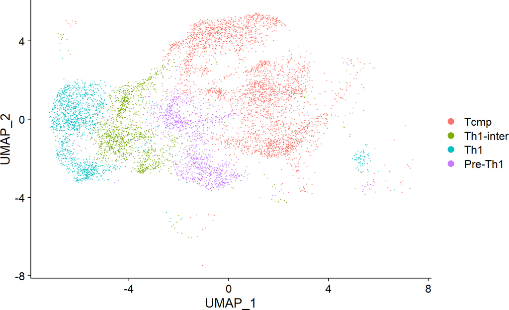

```r
# Visualization--DimPlot
DimPlot(Combined@seurat)
```

```r
# access the cdr3 for first 3 cells
getTCRs(Combined)[1:3]
```

```
#> M1_AAACCTGCAGTGACAG-1 M1_AAACCTGTCAAAGTAG-1 M1_AAACGGGCACCGAATT-1
#>         "CAWSGRDEQYF"      "CASSDRGPNERLFF"        "CAWSLVGDTQYF"
```

```r
# access the clustering labels for first 3 cells
seuratClusterLabels(Combined)[1:3]
```

```
#> M1_AAACCTGCAGTGACAG-1 M1_AAACCTGTCAAAGTAG-1 M1_AAACGGGCACCGAATT-1
#>             Th1-inter                   Th1                  Tcmp
#> Levels: Tcmp Th1-inter Th1 Pre-Th1
```

# 6 Exploratory analysis of clonotypes

After combining the data, users can conduct exploratory analysis of the clonotypes by calling `shinyClone` function.

The `shinyClone` will trigger a Shiny app, which consists of two tabs, ‘Clonotype’ and ‘Repertoire’. ‘Clonotype’ shows a table of clonotype, along with the relevant information, e.g., how many cells are associated with each clonotype and how these cells are distributed among cell clusters. If the user clicks a clonotype in this table, they can also check the distribution of cells associated with each clonotype on the UMAP plot. The plot can also be downloaded by clicking the button below the plot.A cell density plot is also displayed for clones spanning more than 10 cells.

```r
# explore the distribution of clonotypes
shinyClone(Combined)
```

[figure not shown]

The ‘Repertoire’ tab provides commonly used repertoire analysis functionalities, including clonal diversity, clonal homeostasis, clonal proportion, and clonal overlap analyses.

[figure not shown]

The ‘Repertoire’ tab in shinyClone

# 7 T cell trajectory inference

## 7.1 Clonotype-level trajectory inference

Users can infer clonotype-level trajectories using the `getClonotypeLineages` function. Users can control the ways that the trajectories are inferred (for details, please refer to the function documentation). One thing to note is that it is advised to specify the root of the lineage, as the order of lineage is very important for the later lineage clustering step.

The inferred lineages can be accessed via calling the `lrtLineages` function. Users can also take a look at the parameters via calling `lrtParams` function.

```r
load('C:/project/TCR-seq/Gang/GSE158896_RAW/trajectory0801.rda')
```

```r
# infer lineages. Here use Tcmp as the root
Trajectory <- getClonotypeLineages(Combined,start.clus = 'Tcmp', end.clus = NULL, dist.method = 'simple', use.median = TRUE)

# Access one of the inferred lineages
lrtLineages(Trajectory)[[1]]

# Access the parameters
lrtParams(Trajectory)
```

[output not shown]

## 7.2 Trajectory clustering

```r
# clust the lineages
shinyClust(Trajectory,Combined)
```

The `shinyClust` will trigger another Shiny app that allows users to intuitively and dynamically conduct clustering analysis of clonotype-level trajectory. Whenever usres specify the desired number of clusters, `shinyClust` automatically update clustering results. `shinyClust` consists of three tabs, ‘Clustering exploration’, ‘Trajectory clustering’ and ‘DE analysis’.

The ‘Clustering exploration’ tab allows users to implement trajectory clustering in an interactive manner. While SBM is set to be a default here, other clustering algorithms are provided for flexibility, including hierarchical and partitional clustering. Users can also tune parameters for each clustering algorithm. This page will show either ICL or silhouette scores under the current setting, to assist users to evaluate and determine the optimal number of clusters.

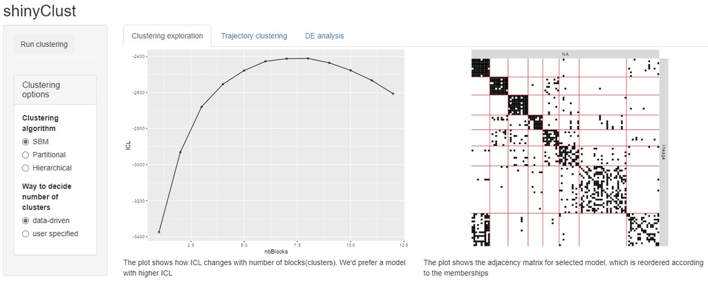

Clustering exploration tab

On the ‘Trajectory clustering’ tab, upon choosing a particular cluster to display, `shinyClust` updates (i) a trajectory plot, which shows clonotype trajectories corresponding to the trajectory cluster on the UMAP plot, and (ii) a cell distribution plot, which shows the cells associated with this trajectory cluster on the UMAP plot.

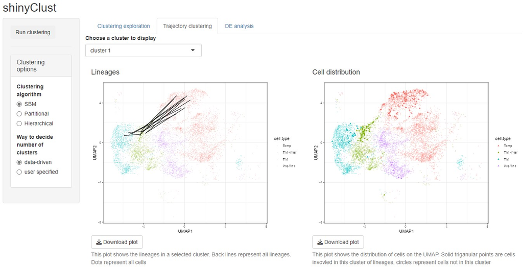

Trajectory clustering tab

## 7.3 Trajectory cluster marker prediction

Finally, in the ‘DE analysis’ tab of the `shinyClust`, users can implement DE analysis, which fits the NB-GAM model and conducts Wald test in the backend using the R package ‘tradeSeq’. Here `shinyClust` shows a table of predicted DE genes with both raw and Bonferroni-adjusted p-values, as well as a heatmap of DE gene expression values. If users are interested in how the expression values of a particular gene vary along pseudotime, they can click the row in the table and the page will show a scatter plot of log read count versus pseudotime, along with the fitted smoothing spline.

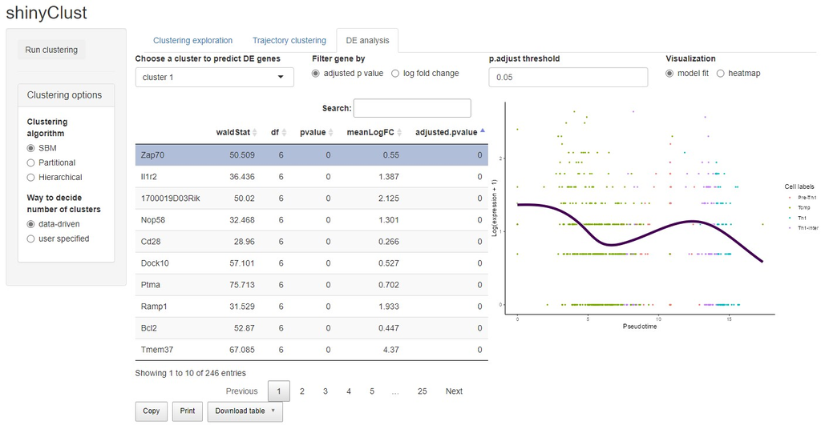

DE analysis tab